# Vu Hoai Phuong Trinh – MBA Portfolio

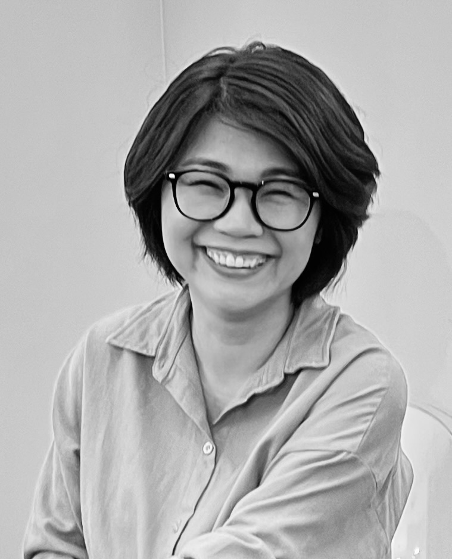

Vu Hoai Phuong Trinh

## Introduction

As an independent individual with an entrepreneurial mindset, I am driven by a passion for innovation and strategic growth. I aim to complete my MBA and establish a small business in British Columbia by 2027. My enthusiasm for exploring new adventures fuels my adaptability and creative problem-solving in professional endeavors. With a deep appreciation for music, I bring a unique perspective and vibrant energy to both personal and business pursuits.

📍 Based in British Columbia, Canada  
🎓 MBA Candidate – University Canada West  
🔗 [LinkedIn](https://www.linkedin.com/in/phuongtrinh149/)

## Education

**MBA in Finance Management**  
University Canada West, Expected September 2025

**Master of Business Administration**  
Open Malaysia University

**Bachelor of Technology in Electronics and Electricity**  
HCMC University of Technology

**Vocational Degree in Accounting**  
University of Economics, Ho Chi Minh City

## Experience

**Sales Associate**  
Hudson Bay (March 2023 – January 2025)  
- Delivered exceptional customer service and contributed to team sales goals  
- Assisted in merchandising and inventory management

**Founder and Business Development**  
Format Vietnam JSC  
- Built company vision and market positioning from the ground up  
- Oversaw strategic growth, client relationships, and business operations

**Sales and Channel Restructuring Project Leader**  
Hafele Vietnam  
- Redesigned sales structures to improve revenue and coverage  
- Implemented strategic tools and processes for sales success

**CRM Project Leader**  
Saint Gobain Vietnam  
- Led cross-functional CRM system implementation  
- Enhanced customer engagement and optimized CRM functionalities

**Cost Controller**  
Holcim Vietnam  
- Analyzed operational costs and identified cost-saving opportunities  
- Supported decision-making through detailed forecasting

## Skills

- Financial Reporting
- Bookkeeping (QuickBooks)
- Budgeting & Forecasting
- Communication
- Microsoft Excel
- Strategic Planning
- Project Management
- CRM Implementation

## Projects & Achievements

**Entrepreneurship at Format VN**  
Founded and developed a scalable business model and built early partnerships in a competitive market.

**Sales Restructuring at Hafele VN**  
Reorganized channel strategies and processes to enhance team efficiency and sales coverage.

**CRM System Launch at Saint Gobain VN**  
Successfully led cross-functional CRM implementation for sales and customer data optimization.

**Cost Controlling at Holcim VN**  
Implemented cost tracking, inter-department collaboration, and budget forecasts to improve efficiency.